# Exercise 1

Gaby Lio, Shirley Zhu, Jushira Thelakkat, Winnie Li

August 10, 2017

## Probability practice

**Part A: What fraction of people who are truthful clickers answered yes?**

- P(RC)=0.3
- P(TC)=0.7
- P(Y|RC)=0.5
- P(N|RC)=0.5
- P(Y)=0.65
- P(N)=0.35

|  | RC | TC | Total |
| --- | --- | --- | --- |
| Y | 0.15 | 0.5 | 0.65 |
| N | 0.15 | 0.2 | 0.35 |
| Total | 0.3 | 0.7 | 1 |

P(Y|TC) = 0.5/0.7 = 71.43%

The fraction of people who answered yes given that they are truthful clickers is 71.43%.

**Part B: Suppose someone tests positive. What is the probability that they have the disease? In light of this calculation, do you envision any problems in implementing a universal testing policy for the disease?**

P(+|D)=0.9993

P(-|Dc)=0.9999

P(D) = 0.000025

P(Dc) = 1-0.000025=0.999975

[output not shown]

P(+,D) = P(+|D) * P(D) = 2.49825e-05

P(-,Dc) =P(-|Dc)* P(Dc) = 0.999875

P(+,Dc) = P(Dc) - P(-,Dc) = 0.999975-0.999875 = 1e-04

P(+) = P(+,D)+P(+,Dc)=2.49825e-05+1e-04=0.0001249825

P(D|+) =P(+,D)/P(+)=2.49825e-05/0.0001249825=0.199888 = **19.99%**

The probability of that someone has the disease given that they test positive is very low, only 19.99%! If they were to implement a universal testing policy for this disease, most people who test positive will not have the disease ~ about 80.01% actually. This would cause chaos, and proves that a universal testing policy for this disease is not recommended.

## Exploratory Analysis: Green Buildings

Looking through the stat gurus summary about green buildings we realized it was flawed in many ways. The first thing he did wrong was deciding to remove buildings that had less than 10% occupancy from the dataset. In our anlaysis we decided to keep these buildings.

We first wanted to check his claims that rent would be higher for a green building, therefore making a green building more profitable, and convincing his boss to build a green building. We created box plots of green building vs. Rent to assert these claims.

```r
green_data = read.csv('greenbuildings.csv')

green_data$renovated = as.factor(green_data$renovated)
green_data$class_a = as.factor(green_data$class_a)
green_data$class_b = as.factor(green_data$class_b)
green_data$green_rating = as.factor(green_data$green_rating)
green_data$LEED = as.factor(green_data$LEED)
green_data$Energystar = as.factor(green_data$Energystar)
green_data$net = as.factor(green_data$net)
green_data$amenities = as.factor(green_data$amenities)
green_data$green_rating = as.factor(green_data$green_rating)
```

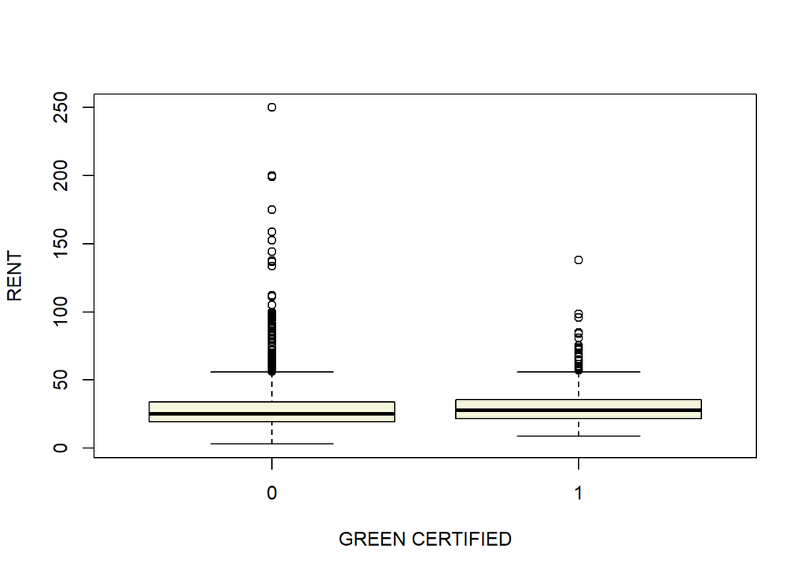

```r
plot(green_data$green_rating, green_data$Rent, xlab='GREEN CERTIFIED', ylab='RENT', col='beige')
```

We found that having a green rating only slightly increased the amount of money you would be able to charge tenants for rent. In fact there is barely any variability between the two averages as shown in the box plots above, making the difference not statistically significant. If you go a step further and compare LEED certified vs. not and Energystar certified vs. not you see that in fact LEED energy buildings which are green certified charge a lower rent.

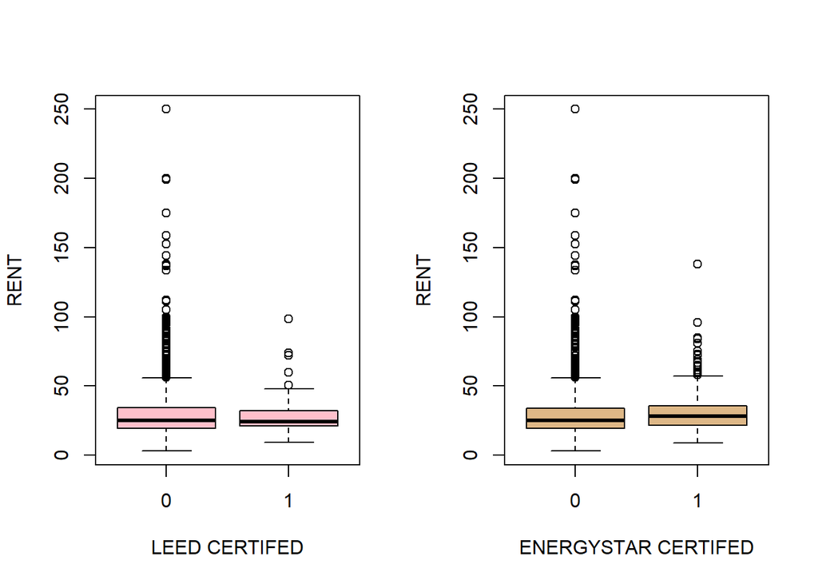

```r
# Compare RENT values vs. being LEED or ENERGYSTAR CERTIFIED
par(mfrow = c(1,2))
plot(green_data$LEED, green_data$Rent, xlab='LEED CERTIFED', ylab='RENT', col='pink')
plot(green_data$Energystar, green_data$Rent, xlab='ENERGYSTAR CERTIFED', ylab='RENT', col='burlywood')
```

This already points in the direction of discrediting the gurus claim of a green building being able to charge tenants more for rent. Another major mistake the GURU did was that he only analyzed the data without looking at possible other confouding variables (i.e. age, stories, anemities, net, etc.). When just analyzing Rent vs. green or not green, you are not taking into account other effects variables have. We decided to run a linear regression to see, if holding all other variables constant, being a green building had a signficant impact on rent.

```r
lmgreen = lm(green_data$Rent~., data=green_data)
summary(lmgreen)
```

```
##
## Call:
## lm(formula = green_data$Rent ~ ., data = green_data)
##
## Residuals:
##     Min      1Q  Median      3Q     Max
## -53.753  -3.581  -0.526   2.491 173.916
##
## Coefficients: (1 not defined because of singularities)
##                     Estimate Std. Error t value Pr(>|t|)
## (Intercept)       -8.315e+00  1.018e+00  -8.167 3.67e-16 ***
## CS_PropertyID      2.959e-07  1.574e-07   1.879 0.060241 .
## cluster            7.532e-04  2.840e-04   2.653 0.008006 **
## size               6.741e-06  6.561e-07  10.276  < 2e-16 ***
## empl_gr            6.450e-02  1.700e-02   3.794 0.000149 ***
## leasing_rate       9.454e-03  5.332e-03   1.773 0.076247 .
## stories           -3.472e-02  1.617e-02  -2.147 0.031823 *
## age               -1.249e-02  4.717e-03  -2.649 0.008096 **
## renovated1        -1.425e-01  2.586e-01  -0.551 0.581681
## class_a1           2.872e+00  4.377e-01   6.563 5.63e-11 ***
## class_b1           1.186e+00  3.427e-01   3.462 0.000539 ***
## LEED1              1.877e+00  3.582e+00   0.524 0.600318
## Energystar1       -2.127e-01  3.818e+00  -0.056 0.955572
## green_rating1      6.969e-01  3.839e+00   0.182 0.855929
## net1              -2.559e+00  5.929e-01  -4.316 1.61e-05 ***
## amenities1         6.703e-01  2.519e-01   2.661 0.007802 **
## cd_total_07       -1.248e-04  1.464e-04  -0.852 0.394005
## hd_total07         5.354e-04  8.972e-05   5.967 2.52e-09 ***
## total_dd_07               NA         NA      NA       NA
## Precipitation      4.830e-02  1.611e-02   2.997 0.002735 **
## Gas_Costs         -3.559e+02  7.842e+01  -4.538 5.76e-06 ***
## Electricity_Costs  1.886e+02  2.493e+01   7.563 4.38e-14 ***
## cluster_rent       1.008e+00  1.421e-02  70.949  < 2e-16 ***
## ---
## Signif. codes:  0 '***' 0.001 '**' 0.01 '*' 0.05 '.' 0.1 ' ' 1
##
## Residual standard error: 9.413 on 7798 degrees of freedom
##   (74 observations deleted due to missingness)
## Multiple R-squared:  0.6126, Adjusted R-squared:  0.6116
## F-statistic: 587.2 on 21 and 7798 DF,  p-value: < 2.2e-16
```

As you can see from the output, when holding all other variables constant, having a green_rating was not significant in affecting Rent at all. Neither was a building having Energystar or LEED certifications (i.e. being green buildings). Other things that had a significant impact on rent included which cluster they belonged in, and each buildings size, age, class, net,amenities, perciption costs, heating days, gas costs, and electricity costs.

We then dived deeper into these insights by seeing if green buildings tended to have amenities thus increasing the price of rent.

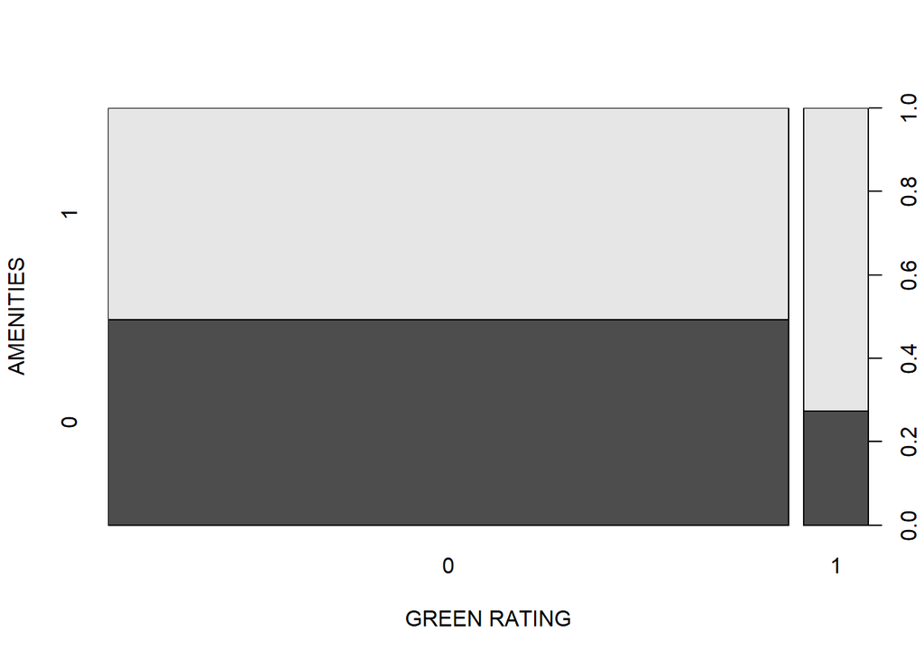

```r
plot(green_data$green_rating, green_data$amenities, xlab='GREEN RATING', ylab='AMENITIES')
```

As you can see from the plot above, about 70% of green buildings have amentities which means this could be influencing the higher price of rent.

We ran the same type of analysis for the variables net, class a, and class b. You can see that most green buildings are class A (about 80%) and few are Class B (about 20%). This proves that the upcharge in price is likely due to the building being class A and not green.

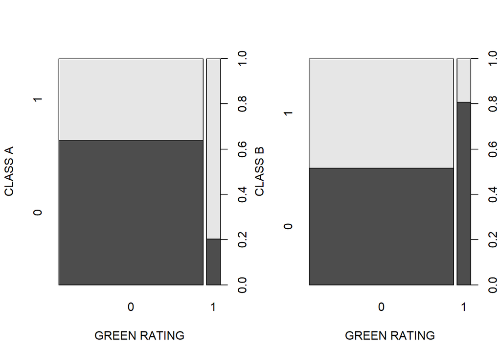

```r
par(mfrow=c(1,2))
plot(green_data$green_rating, green_data$class_a, xlab='GREEN RATING', ylab='CLASS A')
plot(green_data$green_rating, green_data$class_b, xlab='GREEN RATING', ylab='CLASS B')
```

The same goes for the variable net. As you can see below, most green buildings do not have to pay for their own utilities, it is included in the rent costs. Thus adding another confunding variable to why Rent prices could be higher.

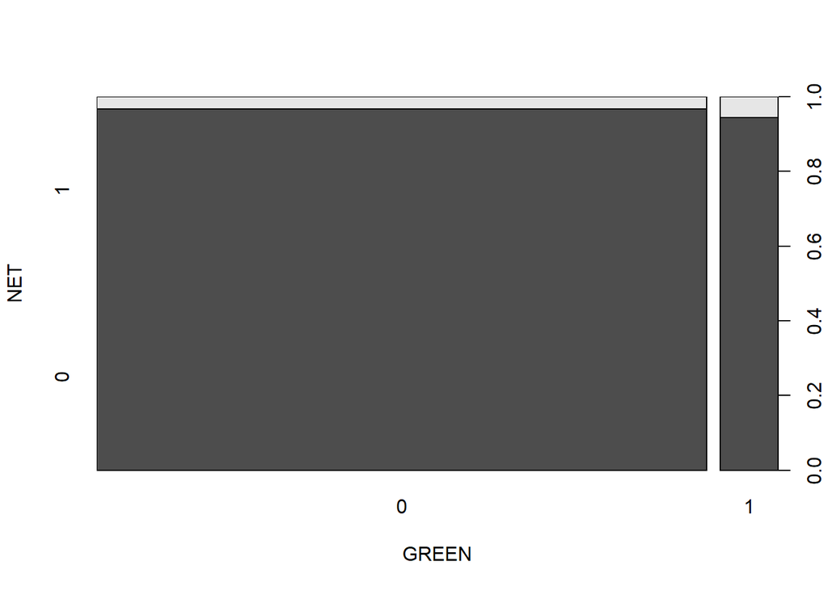

```r
plot(green_data$green_rating, green_data$net, xlab='GREEN', ylab='NET')
```

Lastly, it is told to us in the problem that the building will be 15 stories and will be new. When looking at the relative age of green buildings, they are much lower than non-green buildings.

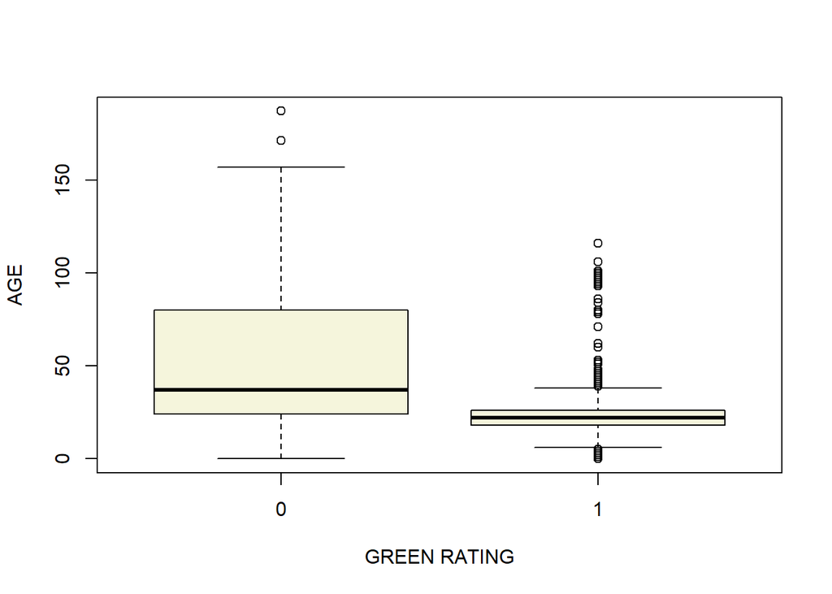

```r
plot(green_data$green_rating, green_data$age, xlab='GREEN RATING', ylab='AGE', col='beige')
```

This is becuase green buildings are a newer concept, and did not exist a while ago. From the linear regression output we can see that Age is a significant variable, and if the building is newer, the rent will tend to be higher than if the building was old. Since most green buildings are newer than non-green buildings this could be another factor affecting the rent price.

Overall, there are too many confounding factors that effect the price of Rent. The guru solely basing his argument on the fact that green buildings have a higher rent is a wrong assumption, and therefore invalidates his analysis.

Taking all other variables into account, the rent price is higher due to many other variables, and not just the fact that the building is green. If we had more data, such as which location cluster the building would fall into, we may be able to predict if the rent of the building would be higher. Since we only know that it will be new and have 15 stories, there is not much more we can predict and the developer should not listen to the gurus anlaysis.

### Market Segmentation

We decided to use clustering to see if we could find the different market segments for the company. As for the data pre-processing, we did not remove any variables but made sure to center and scale the variables before we ran the K-means regression. We figured that K-means would be the simpliest way to identify different segments in the market through clustering.

```r
library(ggplot2)
library(LICORS)  # for kmeans++
library(foreach)
library(mosaic)

socialmarketing = read.csv('social_marketing.csv', header=TRUE)
dim(socialmarketing)
```

```
## [1] 7882   37
```

```r
# Center and scale the data
X = socialmarketing[,-(1:1)]
X = scale(X, center=TRUE, scale=TRUE)
summary(X)
```

```
##     chatter        current_events        travel        photo_sharing
##  Min.   :-1.2464   Min.   :-1.2028   Min.   :-0.6935   Min.   :-0.9873
##  1st Qu.:-0.6797   1st Qu.:-0.4147   1st Qu.:-0.6935   1st Qu.:-0.6212
##  Median :-0.3963   Median :-0.4147   Median :-0.2560   Median :-0.2551
##  Mean   : 0.0000   Mean   : 0.0000   Mean   : 0.0000   Mean   : 0.0000
##  3rd Qu.: 0.4537   3rd Qu.: 0.3733   3rd Qu.: 0.1816   3rd Qu.: 0.4771
##  Max.   : 6.1208   Max.   : 5.1019   Max.   :10.6824   Max.   : 6.7008
##  uncategorized        tv_film         sports_fandom        politics
##  Min.   :-0.8687   Min.   :-0.64522   Min.   :-0.7377   Min.   :-0.59009
##  1st Qu.:-0.8687   1st Qu.:-0.64522   1st Qu.:-0.7377   1st Qu.:-0.59009
##  Median : 0.1998   Median :-0.04237   Median :-0.2749   Median :-0.26018
##  Mean   : 0.0000   Mean   : 0.00000   Mean   : 0.0000   Mean   : 0.00000
##  3rd Qu.: 0.1998   3rd Qu.:-0.04237   3rd Qu.: 0.1879   3rd Qu.: 0.06973
##  Max.   : 8.7482   Max.   : 9.60325   Max.   : 8.5177   Max.   :11.61664
##       food             family        home_and_garden       music
##  Min.   :-0.7871   Min.   :-0.7628   Min.   :-0.7068   Min.   :-0.6595
##  1st Qu.:-0.7871   1st Qu.:-0.7628   1st Qu.:-0.7068   1st Qu.:-0.6595
##  Median :-0.2239   Median : 0.1202   Median :-0.7068   Median :-0.6595
##  Mean   : 0.0000   Mean   : 0.0000   Mean   : 0.0000   Mean   : 0.0000
##  3rd Qu.: 0.3393   3rd Qu.: 0.1202   3rd Qu.: 0.6506   3rd Qu.: 0.3114
##  Max.   : 8.2242   Max.   : 8.0668   Max.   : 6.0803   Max.   :11.9617
##       news          online_gaming        shopping       health_nutrition
##  Min.   :-0.57385   Min.   :-0.4498   Min.   :-0.7681   Min.   :-0.57099
##  1st Qu.:-0.57385   1st Qu.:-0.4498   1st Qu.:-0.7681   1st Qu.:-0.57099
##  Median :-0.57385   Median :-0.4498   Median :-0.2153   Median :-0.34858
##  Mean   : 0.00000   Mean   : 0.0000   Mean   : 0.0000   Mean   : 0.00000
##  3rd Qu.:-0.09784   3rd Qu.:-0.0777   3rd Qu.: 0.3376   3rd Qu.: 0.09625
##  Max.   : 8.94642   Max.   : 9.5968   Max.   : 5.8660   Max.   : 8.54794
##   college_uni      sports_playing       cooking               eco
##  Min.   :-0.5348   Min.   :-0.6552   Min.   :-0.582583   Min.   :-0.6656
##  1st Qu.:-0.5348   1st Qu.:-0.6552   1st Qu.:-0.582583   1st Qu.:-0.6656
##  Median :-0.1897   Median :-0.6552   Median :-0.291032   Median :-0.6656
##  Mean   : 0.0000   Mean   : 0.0000   Mean   : 0.000000   Mean   : 0.0000
##  3rd Qu.: 0.1555   3rd Qu.: 0.3699   3rd Qu.: 0.000518   3rd Qu.: 0.6336
##  Max.   : 9.8202   Max.   : 7.5456   Max.   : 9.038575   Max.   : 7.1294
##    computers          business          outdoors           crafts
##  Min.   :-0.5503   Min.   :-0.6113   Min.   :-0.6471   Min.   :-0.6315
##  1st Qu.:-0.5503   1st Qu.:-0.6113   1st Qu.:-0.6471   1st Qu.:-0.6315
##  Median :-0.5503   Median :-0.6113   Median :-0.6471   Median :-0.6315
##  Mean   : 0.0000   Mean   : 0.0000   Mean   : 0.0000   Mean   : 0.0000
```

[output cut: 15 more lines]

```
##  Max.   : 8.63074   Max.   :13.0666   Max.   : 8.6112   Max.   : 7.2915
##     fashion          small_business         spam
##  Min.   :-0.545049   Min.   :-0.5441   Min.   :-0.07769
##  1st Qu.:-0.545049   1st Qu.:-0.5441   1st Qu.:-0.07769
##  Median :-0.545049   Median :-0.5441   Median :-0.07769
##  Mean   : 0.000000   Mean   : 0.0000   Mean   : 0.00000
##  3rd Qu.: 0.001873   3rd Qu.: 1.0736   3rd Qu.:-0.07769
##  Max.   : 9.299557   Max.   : 9.1623   Max.   :23.93529
##      adult
##  Min.   :-0.2224
##  1st Qu.:-0.2224
##  Median :-0.2224
##  Mean   : 0.0000
##  3rd Qu.:-0.2224
##  Max.   :14.1151
```

```r
# Extract the centers and scales from the rescaled data (which are named attributes)
mu = attr(X,"scaled:center")
sigma = attr(X,"scaled:scale")
```

First we decided to make a plot of the sum of squares vs. the different choices of K to find the optimal K in which to use in our kmeans ++ model. Using the elbow method we found that 4-6 were the optimal numbers for K.

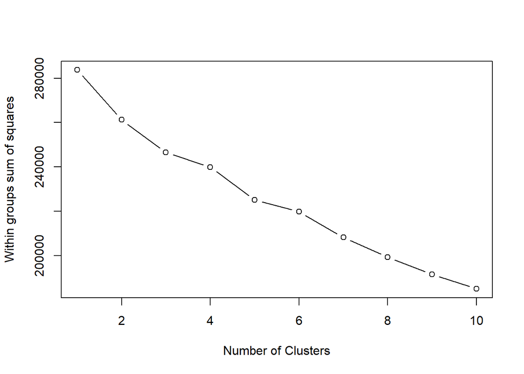

```r
### finding the optimal K###
set.seed(2)
mydata <- X
wss <- (nrow(mydata)-1)*sum(apply(mydata,2,var))
for (i in 2:10) wss[i] <- sum(kmeans(mydata,
                                     centers=i)$withinss)
plot(1:10, wss, type="b", xlab="Number of Clusters",
     ylab="Within groups sum of squares")
```

We ran a kmeans++ model using k=4, k=5, and k=6. Below you can see the outputs for each one. It turns out the using K=4 and K=5, did not give us enough clusters, and that when we used K=6 we could see distinct clusters that differed from one another.

```r
### optimal output from above shows wither 3 or 6 for k so lets try both
set.seed(1)
clust5 = kmeanspp(X, k=5, nstart=25)


#cluster 3 centers
clust5$center[1,]*sigma + mu #chatter, photo_sharing, not active
```

```
##          chatter   current_events           travel    photo_sharing
##      4.272972973      1.445945946      1.112266112      2.274220374
##    uncategorized          tv_film    sports_fandom         politics
##      0.729937630      1.036798337      0.977130977      1.006860707
##             food           family  home_and_garden            music
##      0.778586279      0.595634096      0.444282744      0.575467775
##             news    online_gaming         shopping health_nutrition
##      0.686486486      1.159459459      1.252182952      1.067359667
##      college_uni   sports_playing          cooking              eco
##      1.502494802      0.549272349      0.844074844      0.388357588
##        computers         business         outdoors           crafts
##      0.372557173      0.337006237      0.402079002      0.371725572
##       automotive              art         religion           beauty
##      0.592515593      0.657588358      0.527442827      0.336798337
##        parenting           dating           school personal_fitness
##      0.463201663      0.528690229      0.462577963      0.645322245
##          fashion   small_business             spam            adult
##      0.509979210      0.284615385      0.006652807      0.417879418
```

```r
clust5$center[2,]*sigma + mu #cooking, fashion, beauty, chatter, photo sharing
```

```
##          chatter   current_events           travel    photo_sharing
##      5.377880184      1.764976959      1.509984639      6.129032258
##    uncategorized          tv_film    sports_fandom         politics
##      1.288786482      1.153609831      1.165898618      1.411674347
##             food           family  home_and_garden            music
##      1.105990783      0.929339478      0.652841782      1.278033794
##             news    online_gaming         shopping health_nutrition
##      1.024577573      1.528417819      2.195084485      2.152073733
##      college_uni   sports_playing          cooking              eco
##      2.070660522      0.964669739     10.038402458      0.589861751
##        computers         business         outdoors           crafts
##      0.738863287      0.635944700      0.807987711      0.643625192
##       automotive              art         religion           beauty
##      0.917050691      0.943164363      0.850998464      3.648233487
##        parenting           dating           school personal_fitness
##      0.784946237      1.184331797      1.033794163      1.314900154
##          fashion   small_business             spam            adult
##      5.247311828      0.543778802      0.003072197      0.439324117
```

```r
clust5$center[3,]*sigma + mu #chatter, photo sharing, personal fitness, health nutrition
```

```
##          chatter   current_events           travel    photo_sharing
##      4.377825619      1.553283100      1.232508073      2.672766416
##    uncategorized          tv_film    sports_fandom         politics
##      0.976318622      1.032292788      1.163616792      1.226049516
##             food           family  home_and_garden            music
##      2.120559742      0.791173305      0.636167922      0.762109795
##             news    online_gaming         shopping health_nutrition
##      1.087190527      1.196986006      1.473627557     11.907427341
##      college_uni   sports_playing          cooking              eco
##      1.342303552      0.696447793      3.256189451      0.913885899
##        computers         business         outdoors           crafts
##      0.551130248      0.472551130      2.699677072      0.594187298
##       automotive              art         religion           beauty
##      0.675995694      0.753498385      0.763186222      0.418729817
##        parenting           dating           school personal_fitness
##      0.759956943      1.013993541      0.585575888      6.373519914
##          fashion   small_business             spam            adult
##      0.792249731      0.290635091      0.006458558      0.425188375
```

```r
clust5$center[4,]*sigma + mu #chatter, photo sharing, parenting, sports fandom, food, family
```

```
##          chatter   current_events           travel    photo_sharing
##      4.258598726      1.672611465      1.355414013      2.630573248
##    uncategorized          tv_film    sports_fandom         politics
##      0.761783439      1.115923567      5.868789809      1.168152866
##             food           family  home_and_garden            music
##      4.532484076      2.485350318      0.657324841      0.757961783
##             news    online_gaming         shopping health_nutrition
##      1.040764331      1.289171975      1.470063694      1.852229299
##      college_uni   sports_playing          cooking              eco
##      1.538853503      0.797452229      1.577070064      0.656050955
##        computers         business         outdoors           crafts
##      0.741401274      0.500636943      0.701910828      1.080254777
##       automotive              art         religion           beauty
##      1.047133758      0.898089172      5.242038217      1.077707006
##        parenting           dating           school personal_fitness
##      4.019108280      0.770700637      2.685350318      1.191082803
##          fashion   small_business             spam            adult
##      1.001273885      0.410191083      0.006369427      0.405095541
```

```r
clust5$center[5,]*sigma + mu #chatter, photo_sharing, news, politics, travel,
```

```
##          chatter   current_events           travel    photo_sharing
##      4.536067893      1.654879774      5.588401697      2.516265912
##    uncategorized          tv_film    sports_fandom         politics
##      0.782178218      1.220650636      2.004243281      8.882602546
##             food           family  home_and_garden            music
##      1.445544554      0.923620934      0.615275813      0.637906648
##             news    online_gaming         shopping health_nutrition
##      5.241867044      1.176803395      1.380480905      1.674681754
##      college_uni   sports_playing          cooking              eco
##      1.673267327      0.700141443      1.261669024      0.596888260
##        computers         business         outdoors           crafts
##      2.473833098      0.663366337      0.919377652      0.649222065
##       automotive              art         religion           beauty
##      2.325318246      0.751060820      1.016973126      0.463932107
##        parenting           dating           school personal_fitness
##      0.936350778      1.049504950      0.708628006      1.001414427
##          fashion   small_business             spam            adult
##      0.656294201      0.475247525      0.008486563      0.240452617
```

```r
#checking to see sum of squares
clust5$tot.withinss
```

```
## [1] 224580
```

```r
clust5$betweenss
```

```
## [1] 59136.04
```

```r
options(scipen=999)

set.seed(1)
clust4 = kmeanspp(X, k=4, nstart=25)
#cluster 4  centers
clust4$center[1,]*sigma + mu # food, sports fandom, religion, parenting
```

```
##          chatter   current_events           travel    photo_sharing
##      4.109375000      1.679687500      1.342447917      2.548177083
##    uncategorized          tv_film    sports_fandom         politics
##      0.746093750      1.052083333      5.962239583      1.186197917
##             food           family  home_and_garden            music
##      4.609375000      2.519531250      0.648437500      0.726562500
##             news    online_gaming         shopping health_nutrition
##      1.039062500      1.272135417      1.404947917      2.182291667
##      college_uni   sports_playing          cooking              eco
##      1.454427083      0.766927083      1.733072917      0.652343750
##        computers         business         outdoors           crafts
##      0.743489583      0.503906250      0.748697917      1.080729167
##       automotive              art         religion           beauty
##      1.050781250      0.884114583      5.364583333      1.106770833
##        parenting           dating           school personal_fitness
##      4.104166667      0.664062500      2.704427083      1.394531250
##          fashion   small_business             spam            adult
##      1.040364583      0.389322917      0.006510417      0.425781250
```

```r
clust4$center[2,]*sigma + mu # not active
```

```
##          chatter   current_events           travel    photo_sharing
##       3.66717724       1.37221007       1.06236324       1.88402626
##    uncategorized          tv_film    sports_fandom         politics
##       0.67242888       0.82122538       0.94332604       0.95448578
##             food           family  home_and_garden            music
##       0.79846827       0.55667396       0.40612691       0.47833698
##             news    online_gaming         shopping health_nutrition
##       0.69102845       0.93654267       0.98008753       1.52582057
##      college_uni   sports_playing          cooking              eco
##       1.15536105       0.45207877       0.92910284       0.34748359
##        computers         business         outdoors           crafts
##       0.35536105       0.28971554       0.49059081       0.32253829
##       automotive              art         religion           beauty
##       0.54288840       0.48927790       0.51597374       0.31947484
##        parenting           dating           school personal_fitness
##       0.44923414       0.42954048       0.40131291       0.86564551
##          fashion   small_business             spam            adult
##       0.46673961       0.23216630       0.00547046       0.38052516
```

```r
clust4$center[3,]*sigma + mu #travel, politics, news
```

```
##          chatter   current_events           travel    photo_sharing
##      4.404761905      1.656862745      5.627450980      2.445378151
##    uncategorized          tv_film    sports_fandom         politics
##      0.782913165      1.142857143      2.042016807      8.990196078
##             food           family  home_and_garden            music
##      1.460784314      0.929971989      0.610644258      0.633053221
##             news    online_gaming         shopping health_nutrition
##      5.284313725      1.138655462      1.301120448      2.029411765
##      college_uni   sports_playing          cooking              eco
##      1.532212885      0.707282913      1.406162465      0.591036415
##        computers         business         outdoors           crafts
##      2.476190476      0.644257703      1.001400560      0.607843137
##       automotive              art         religion           beauty
##      2.362745098      0.679271709      1.023809524      0.512605042
##        parenting           dating           school personal_fitness
##      0.960784314      1.047619048      0.722689076      1.189075630
##          fashion   small_business             spam            adult
##      0.731092437      0.473389356      0.008403361      0.238095238
```

```r
clust4$center[4,]*sigma + mu #cooking, fashion, shopping, health_nutrition
```

```
##          chatter   current_events           travel    photo_sharing
##      6.344808743      1.795628415      1.414754098      4.886885246
##    uncategorized          tv_film    sports_fandom         politics
##      1.203825137      1.671584699      1.210928962      1.314754098
##             food           family  home_and_garden            music
##      1.520765027      0.910382514      0.718032787      1.179234973
##             news    online_gaming         shopping health_nutrition
##      0.968852459      1.889617486      2.439344262      5.539344262
##      college_uni   sports_playing          cooking              eco
##      2.580327869      1.026229508      5.010382514      0.834426230
##        computers         business         outdoors           crafts
##      0.630054645      0.636612022      1.440983607      0.725683060
##       automotive              art         religion           beauty
##      0.855737705      1.263934426      0.778688525      1.574863388
##        parenting           dating           school personal_fitness
##      0.749180328      1.301639344      0.887431694      3.086338798
##          fashion   small_business             spam            adult
##      2.404918033      0.520765027      0.008196721      0.515300546
```

```r
#checking to see sum of squares
clust4$tot.withinss
```

```
## [1] 234995.5
```

```r
clust4$betweenss
```

```
## [1] 48720.5
```

```r
set.seed(1)
clust6 = kmeanspp(X, k=6, nstart=25)
#cluster 6  centers
clust6$center[1,]*sigma + mu #chatter, photo sharing
```

```
##          chatter   current_events           travel    photo_sharing
##      4.328492849      1.444664466      1.099229923      2.296149615
##    uncategorized          tv_film    sports_fandom         politics
##      0.728272827      1.003080308      0.970517052      1.010341034
##             food           family  home_and_garden            music
##      0.769416942      0.573157316      0.440044004      0.562596260
##             news    online_gaming         shopping health_nutrition
##      0.692409241      0.588778878      1.278987899      1.091529153
##      college_uni   sports_playing          cooking              eco
##      0.908910891      0.421122112      0.862926293      0.389658966
##        computers         business         outdoors           crafts
##      0.373817382      0.339053905      0.401760176      0.363256326
##       automotive              art         religion           beauty
##      0.580858086      0.622002200      0.526732673      0.354015402
##        parenting           dating           school personal_fitness
##      0.458525853      0.543234323      0.477227723      0.659845985
##          fashion   small_business             spam            adult
##      0.514851485      0.277667767      0.006820682      0.416501650
```

```r
clust6$center[2,]*sigma + mu #online gaming, college universities
```

```
##          chatter   current_events           travel    photo_sharing
##      4.482517483      1.487179487      1.573426573      2.818181818
##    uncategorized          tv_film    sports_fandom         politics
##      0.913752914      1.699300699      1.335664336      1.307692308
##             food           family  home_and_garden            music
##      1.247086247      1.079254079      0.613053613      0.955710956
##             news    online_gaming         shopping health_nutrition
##      0.797202797      9.694638695      1.365967366      1.783216783
##      college_uni   sports_playing          cooking              eco
##     10.564102564      2.613053613      1.482517483      0.489510490
##        computers         business         outdoors           crafts
##      0.585081585      0.417249417      0.659673660      0.603729604
##       automotive              art         religion           beauty
##      0.909090909      1.233100233      0.811188811      0.442890443
##        parenting           dating           school personal_fitness
##      0.675990676      0.748251748      0.512820513      1.025641026
##          fashion   small_business             spam            adult
##      0.899766900      0.461538462      0.009324009      0.445221445
```

```r
clust6$center[3,]*sigma + mu #health nutrition, personal fitness
```

```
##          chatter   current_events           travel    photo_sharing
##      4.354729730      1.559684685      1.244369369      2.654279279
##    uncategorized          tv_film    sports_fandom         politics
##      0.966216216      0.984234234      1.163288288      1.255630631
##             food           family  home_and_garden            music
##      2.129504505      0.773648649      0.636261261      0.739864865
##             news    online_gaming         shopping health_nutrition
##      1.106981982      0.841216216      1.458333333     12.010135135
##      college_uni   sports_playing          cooking              eco
##      0.933558559      0.604729730      3.281531532      0.918918919
##        computers         business         outdoors           crafts
##      0.561936937      0.470720721      2.740990991      0.588963964
##       automotive              art         religion           beauty
##      0.663288288      0.740990991      0.762387387      0.424549550
##        parenting           dating           school personal_fitness
##      0.761261261      1.038288288      0.596846847      6.438063063
##          fashion   small_business             spam            adult
##      0.800675676      0.293918919      0.006756757      0.416666667
```

```r
clust6$center[4,]*sigma + mu # sports fandom, parenting, religion
```

```
##          chatter   current_events           travel    photo_sharing
##      4.238219895      1.679319372      1.349476440      2.629581152
##    uncategorized          tv_film    sports_fandom         politics
##      0.752617801      1.090314136      5.888743455      1.166230366
##             food           family  home_and_garden            music
##      4.565445026      2.492146597      0.643979058      0.744764398
##             news    online_gaming         shopping health_nutrition
##      1.040575916      1.006544503      1.469895288      1.854712042
##      college_uni   sports_playing          cooking              eco
##      1.229057592      0.743455497      1.587696335      0.659685864
##        computers         business         outdoors           crafts
##      0.731675393      0.502617801      0.691099476      1.085078534
##       automotive              art         religion           beauty
##      1.049738220      0.870418848      5.252617801      1.090314136
##        parenting           dating           school personal_fitness
##      4.049738220      0.776178010      2.698952880      1.191099476
##          fashion   small_business             spam            adult
##      1.005235602      0.404450262      0.005235602      0.409685864
```

```r
clust6$center[5,]*sigma + mu # politics, travel, news
```

```
##          chatter   current_events           travel    photo_sharing
##      4.548387097      1.667155425      5.612903226      2.541055718
##    uncategorized          tv_film    sports_fandom         politics
##      0.775659824      1.199413490      2.014662757      8.960410557
##             food           family  home_and_garden            music
##      1.441348974      0.913489736      0.611436950      0.640762463
##             news    online_gaming         shopping health_nutrition
##      5.318181818      0.828445748      1.379765396      1.639296188
##      college_uni   sports_playing          cooking              eco
##      1.318181818      0.629032258      1.259530792      0.593841642
##        computers         business         outdoors           crafts
##      2.473607038      0.670087977      0.916422287      0.640762463
##       automotive              art         religion           beauty
##      2.347507331      0.718475073      1.030791789      0.473607038
##        parenting           dating           school personal_fitness
##      0.947214076      1.068914956      0.725806452      1.000000000
##          fashion   small_business             spam            adult
##      0.668621701      0.483870968      0.005865103      0.236070381
```

```r
clust6$center[6,]*sigma + mu # fashion, cooking, beauty, photo sharing
```

```
##          chatter   current_events           travel    photo_sharing
##      4.996515679      1.778745645      1.494773519      6.118466899
##    uncategorized          tv_film    sports_fandom         politics
##      1.296167247      1.085365854      1.174216028      1.442508711
##             food           family  home_and_garden            music
##      1.081881533      0.918118467      0.639372822      1.261324042
##             news    online_gaming         shopping health_nutrition
##      1.059233449      1.066202091      2.078397213      2.280487805
##      college_uni   sports_playing          cooking              eco
##      1.538327526      0.817073171     10.811846690      0.578397213
##        computers         business         outdoors           crafts
##      0.733449477      0.621951220      0.824041812      0.639372822
##       automotive              art         religion           beauty
##      0.904181185      0.947735192      0.869337979      3.878048780
##        parenting           dating           school personal_fitness
##      0.822299652      0.991289199      1.001742160      1.351916376
##          fashion   small_business             spam            adult
##      5.564459930      0.506968641      0.003484321      0.437282230
```

```r
#checking to see sum of squares
clust6$tot.withinss
```

```
## [1] 214481.4
```

```r
clust6$betweenss
```

```
## [1] 69234.64
```

Usin k=6, we found the following clusters to represent the following market segments:

1. Cluster 1
- Focused around those who just used a lot of chatter or photo sharing, and did not really focus on any specific topic when tweeting. They also did not seem to be using twitter a lot since their counts were low in every topic.
2. Cluster 2
- Focused around people who mentioned online gaming or college universities a lot. We figures that this could be a young male population consisting of 16-22 year olds who are active on twitter.
3. Cluster 3
- Focused around people who talked a lot about health nutrition and personal fitness. This customer segment could possibly be young adults or adults who are very into fitness and staying healthy, and who regulary attend the gym and eat nutrious foods.
4. Cluster 4
- Focused around sports fandom, parenting and religion. This customer segment more liekly than not represents the parents of families who have children, therefore consisting of an older adult crowd.
5. Cluster 5
- Focused around those who mentioned politics, travel, automotive, computers and news. This customer segment probably consits of older men who are educated and probably have more money.
6. Cluster 6
- Focused on cooking, fashion, and beauty. This cusomter segment probably represents mothers or adult/young adult women.

Below we plotted some of the key variables that represent every customer segment using K=6.

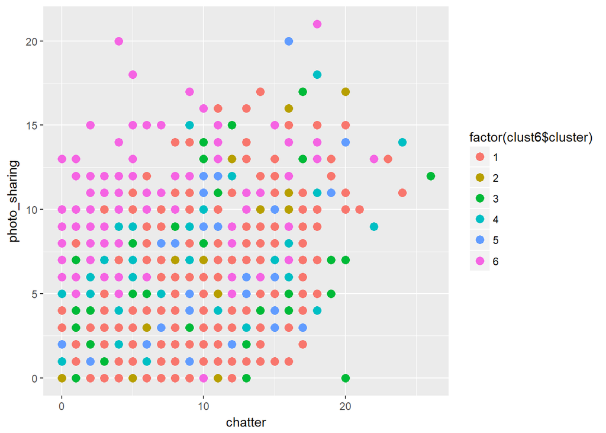

```r
# qplot is in the ggplot2 library
qplot(chatter, photo_sharing,data=socialmarketing, size=I(3), color=factor(clust6$cluster))
```

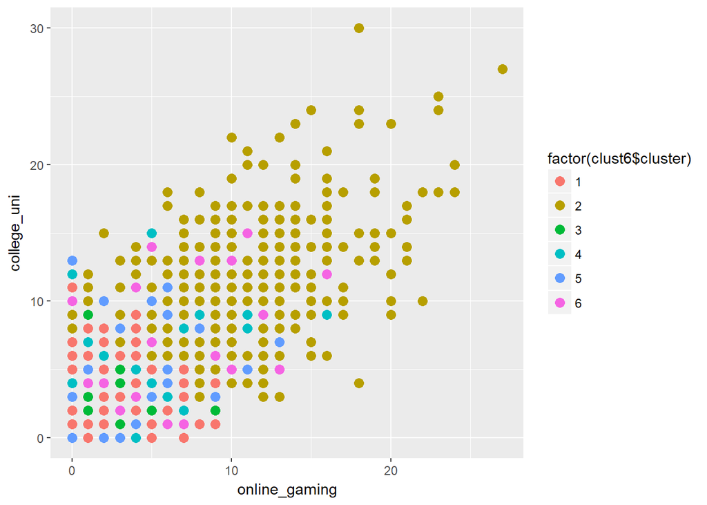

```r
qplot(online_gaming, college_uni,data=socialmarketing, size=I(3), color=factor(clust6$cluster))
```

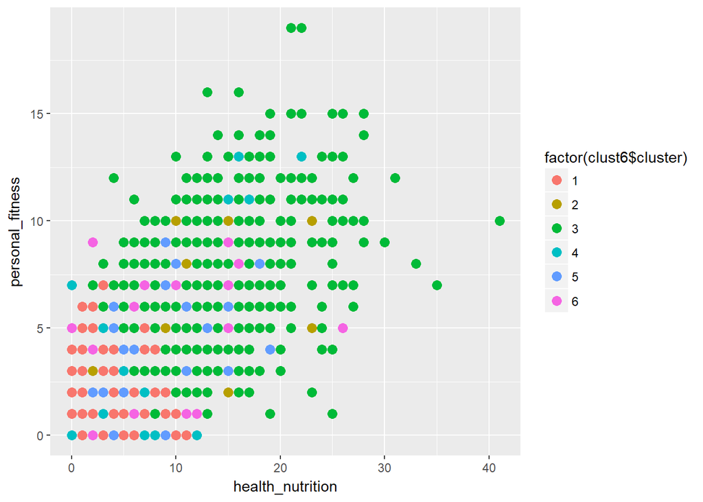

```r
qplot(health_nutrition, personal_fitness, data=socialmarketing, size=I(3), color=factor(clust6$cluster))
```

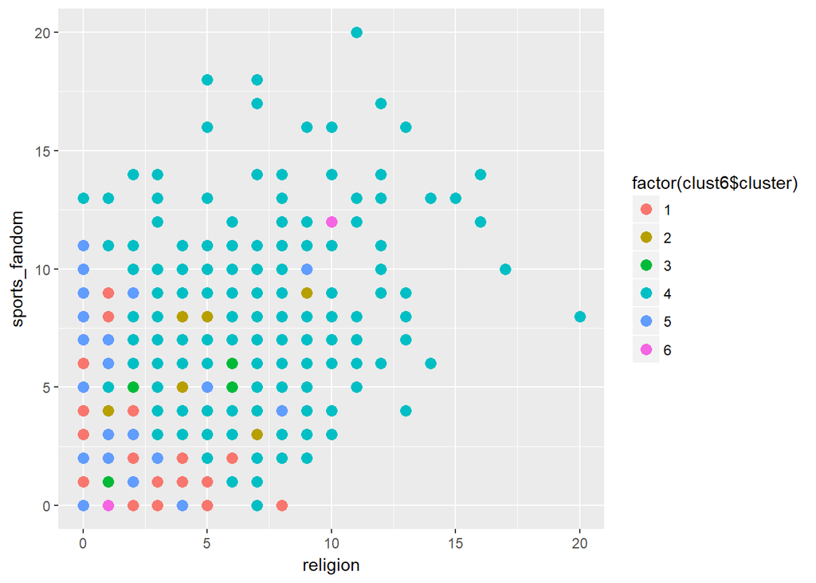

```r
qplot(religion, sports_fandom, data=socialmarketing, size=I(3), color=factor(clust6$cluster))
```

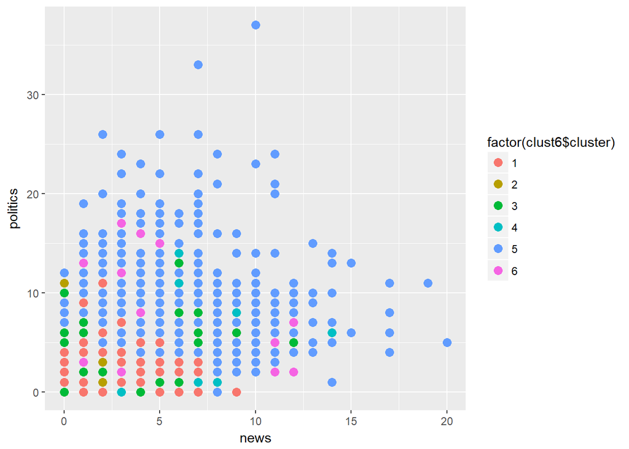

```r
qplot(news, politics,data=socialmarketing, size=I(3), color=factor(clust6$cluster))
```

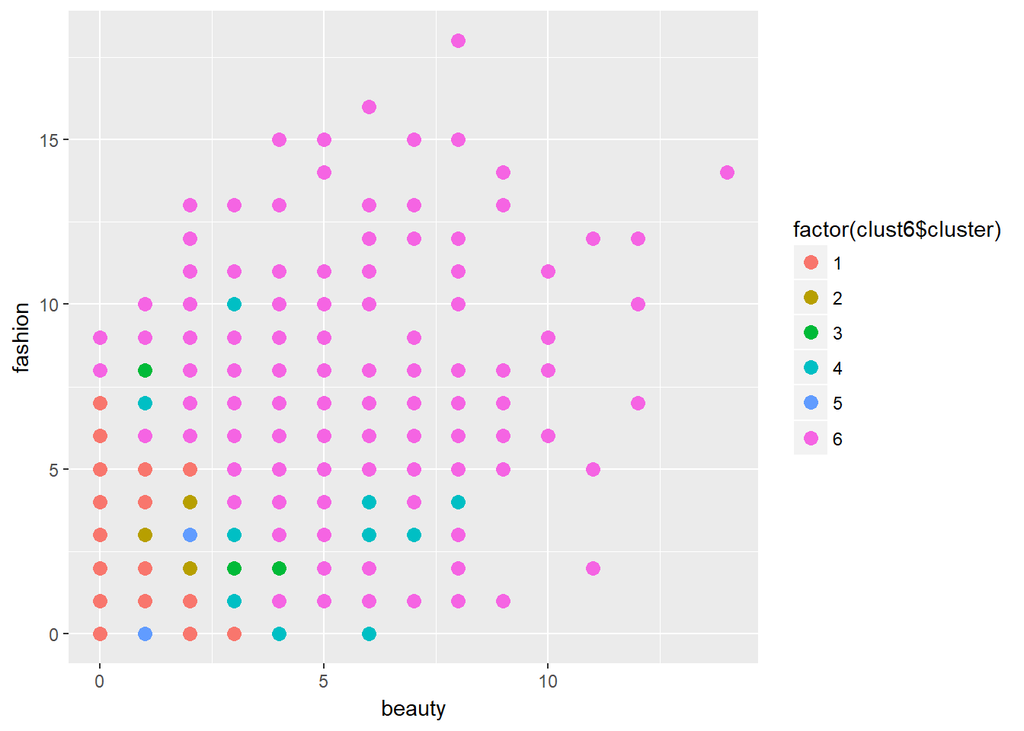

```r
qplot(beauty, fashion,data=socialmarketing, size=I(3), color=factor(clust6$cluster))
```